# Estimating Correlation Parameters Based on the Variogram on Binary Variables

Erick A. Chacon-Montalvan

2018-02-05

This is just an example of how the estimated parameters of the variogram of a binary response can be transformed to the intercept $\beta_0$ and variance $\sigma^2$ of a probit model.

```r
rm(list = ls())
library(ggplot2)
library(datasim)
library(tidyverse)
```

### COMPARE GAUSSIAN PROCESSES

In order to test the adequacy of our method, we simulate different spatial binary variables obtained from probit model with different values of intercept $\beta_0$, variance of the Gaussian process $\sigma^2$ and range parameter $\phi$.

```r
set.seed(10)
n <- 4000
data_pred <- tibble::tibble(id = 1:n, s1 = runif(n), s2 = runif(n))
(data <- gp_probit_sim(data_pred,
                       beta0 = c(-0.5, 0, 0.8),
                       sigma2 = c(0.5, 1, 1.5, 2),
                       phi = c(0.03, 0.05)))
```

```
#> # A tibble: 96,000 x 10
#>     beta0 sigma2    phi    id     s1     s2      gp   prob  size response
#>     <dbl>  <dbl>  <dbl> <int>  <dbl>  <dbl>   <dbl>  <dbl> <dbl>    <int>
#>  1 -0.500  0.500 0.0300     1 0.507  0.379  -0.952  0.0733  1.00        0
#>  2 -0.500  0.500 0.0300     2 0.307  0.0744  0.983  0.685   1.00        1
#>  3 -0.500  0.500 0.0300     3 0.427  0.776   0.312  0.425   1.00        0
#>  4 -0.500  0.500 0.0300     4 0.693  0.991  -1.07   0.0587  1.00        0
#>  5 -0.500  0.500 0.0300     5 0.0851 0.283  -0.183  0.247   1.00        0
#>  6 -0.500  0.500 0.0300     6 0.225  0.267  -1.17   0.0471  1.00        0
#>  7 -0.500  0.500 0.0300     7 0.275  0.174  -0.0641 0.286   1.00        0
#>  8 -0.500  0.500 0.0300     8 0.272  0.895   0.540  0.516   1.00        0
#>  9 -0.500  0.500 0.0300     9 0.616  0.489  -0.343  0.200   1.00        0
#> 10 -0.500  0.500 0.0300    10 0.430  0.849   0.476  0.490   1.00        1
#> # ... with 95,990 more rows
```

### VISUALIZATION OF THE SIMULATED DATA

#### Gaussian Processes

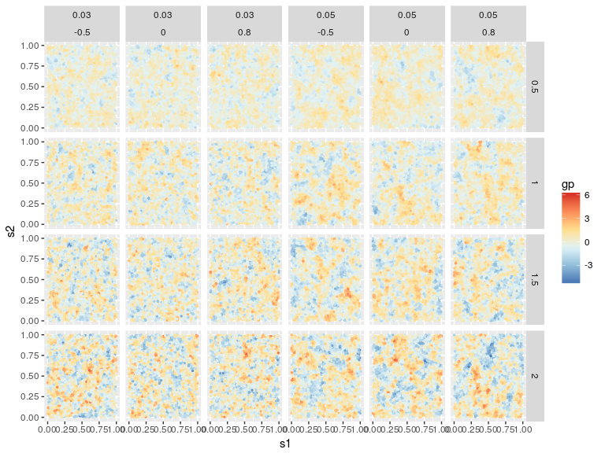

```r
ggplot(data, aes(s1, s2)) +
  geom_point(aes(col = gp), size = 0.5) +
  scale_colour_distiller(palette = "RdYlBu") +
  facet_grid(sigma2 ~ phi + beta0, scales = "free")
```

#### Binary Response Data

As expected, the intercept $\beta_0$ `= c(-0.5, 0, 0.8)` plays a main role in defining the proportion of successes. The expected number of successes increase as the value of $c$ increases.

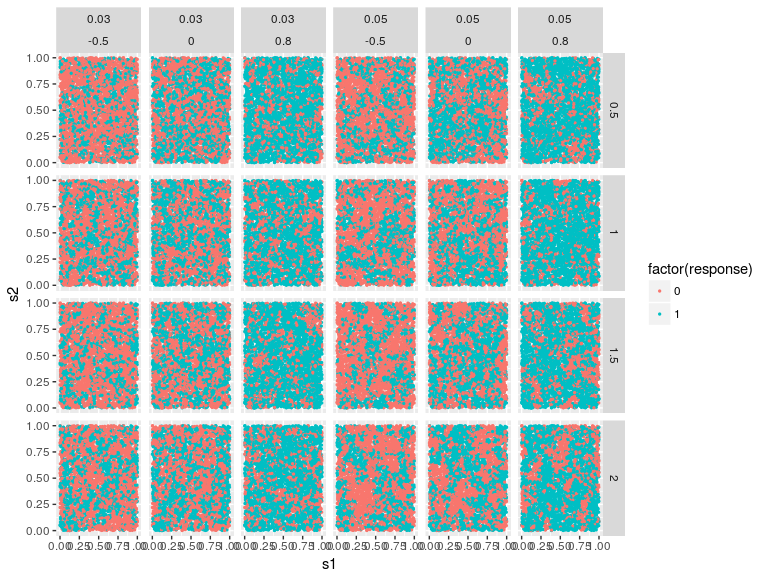

```r
ggplot(data, aes(s1, s2)) +
  geom_point(aes(col = factor(response)), size = 0.5) +
  facet_grid(sigma2 ~ phi + beta0, scales = "free")
```

### THE VARIOGRAMS

#### Gaussian Processes

We can plot the theoretical variogram with the empirical because we know the real parameters. We can use the following functions.

```r
exp_vg <- function (vg, phi, sigma2, nugget = 0) {
  nugget + sigma2 * (1 - exp(-vg$dist / phi))
}
gp_vgs <- data %>%
  group_by(beta0, phi, sigma2) %>%
  nest() %>%
  mutate(
    vg = purrr::map(data,
      ~ gstat::variogram(gp ~ 1, ~ s1 + s2, ., cutoff = 0.8, width = 0.005)),
    vg_theor = purrr::pmap(list(vg, phi, sigma2), exp_vg)
    ) %>%
  select(-data) %>%
  unnest()
```

And visualize the empirical and theoretical variogram of the gaussian process.

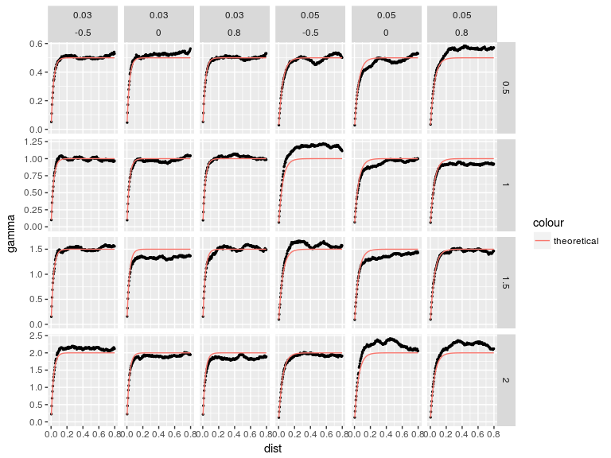

```r
ggplot(gp_vgs, aes(dist, gamma)) +
  geom_point(size = 0.5) +
  geom_line(aes(y = vg_theor, col = "theoretical"), size = 0.5) +
  expand_limits(y = 0, x = 0) +
  scale_x_continuous(limits = c(0, 0.8)) +
  facet_grid(sigma2 ~ phi + beta0, scales = "free")
```

#### Binary Response Data

In real applications we do not have the realization of the Gaussian process, but we can still know the characteristics of the variogram of the binary outcome based on the parameters $\beta_0$, $\sigma^2$ (we assume that $phi$ is not drastically different). Although the relationship is not straightforward, we can obtained it using the following functions.

```r
get_sill <- function (beta0, sigma2) {
  prop <- mean(pnorm(rnorm(10^5, beta0, sd = sigma2^0.5)))
  return(prop * (1 - prop))
}

get_sigma2 <- function (beta0, sigma2) {
  sigma2 <- var(pnorm(rnorm(10^5, beta0, sd = sigma2^0.5)))
  return(sigma2)
}

get_nugget <- function (beta0, sigma2) {
  nugget <- get_sill(beta0, sigma2) - get_sigma2(beta0, sigma2)
  return(nugget)
}

exp_vg_bi <- function (vg, phi, sigma2, beta0) {
  get_nugget(beta0, sigma2) + get_sigma2(beta0, sigma2) * (1 - exp(-vg$dist / phi))
}


bi_vgs <- data %>%
  group_by(beta0, phi, sigma2) %>%
  nest() %>%
  mutate(
    vg = purrr::map(
      data,
      ~ gstat::variogram(response ~ 1, ~ s1 + s2, ., cutoff = 0.8, width = 0.005)),
    vg_theor = purrr::pmap(list(vg, phi, sigma2, beta0), exp_vg_bi)
    ) %>%
  select(-data) %>%
  unnest()
```

What we show is that we can understand how the binary variogram will look like for given parameters of the probit model.

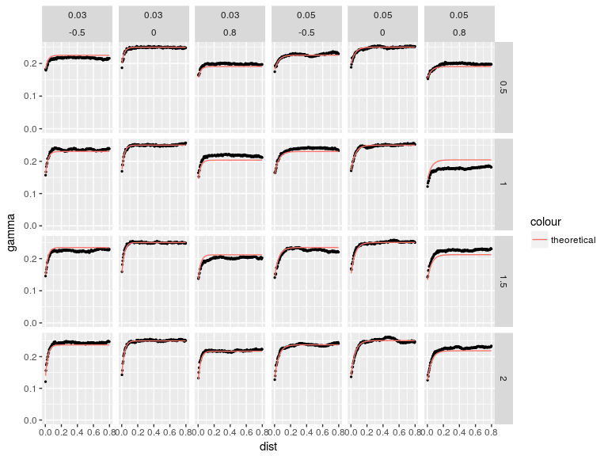

```r
ggplot(bi_vgs, aes(dist, gamma)) +
  geom_point(size = 0.5) +
  expand_limits(y = 0, x = 0) +
  scale_x_continuous(limits = c(0, 0.8)) +
  geom_line(aes(y = vg_theor, col = "theoretical"), size = 0.5) +
  facet_grid(sigma2 ~ phi + beta0, scales = "free")
```

### ESTIMATING THE PARAMETERS ON THE ORIGINAL SCALE

It has been show that the sill and the nugget effect of the variogram on the transformed scale can be obtained from the original parameters. Then it is logical to think that we can obtained the real parameters back by using the empirical estimates of the variogram on the transformed scale. We achieve it using the following functions.

```r
cost_moments <- function (param, mean, var) {
  beta0 <- param[1]
  sigma2 <- exp(param[2])
  x <- rnorm(10^5, beta0, sd = sigma2^0.5)
  mean_bi <- mean(pnorm(x))
  var_bi <- var(pnorm(x))
  return(log((mean_bi - mean) ^ 2 + (var_bi - var) ^ 2))
}

fit_variog_bin <- function (variog, mean, var, ...) {
  vg_fit <- gstat::fit.variogram(variog, ...)
  init <- c(0, log(0.5))
  par <- optim(init, cost_moments, mean = mean, var = var - vg_fit$psill[1])
  return(c(par$par[1], exp(par$par[2]), vg_fit$range[2]))
}

fit_variog_exp <- function (variog, mean, var) {
  fit_variog_bin(variog, mean, var,
                 model = gstat::vgm(0.4 * var,"Exp", 0.04, nugget = 0.6 * var))
}

bi_vgs <- data %>%
  group_by(beta0, phi, sigma2) %>%
  nest() %>%
  mutate(
    mean = purrr::map_dbl(data, ~ mean(.$response)),
    var = purrr::map_dbl(data, ~ var(.$response)),
    vg = purrr::map(
      data,
      ~ gstat::variogram(response ~ 1, ~ s1 + s2, ., cutoff = 0.6, width = 0.005)),
    vg_est0 = purrr::pmap(list(vg, mean, var),
                           purrr::possibly(fit_variog_exp,  rep(NA_real_))),
    beta0_est = purrr::map_dbl(vg_est0, ~ .[1]),
    sigma2_est = purrr::map_dbl(vg_est0, ~ .[2]),
    phi_est = purrr::map_dbl(vg_est0, ~ .[3]),
    vg_est = purrr::pmap(list(vg, phi_est, sigma2_est, beta0_est), exp_vg_bi)
    ) %>%
  select(-data, -vg_est0) %>%
  unnest()
```

### VISUALIZING THE FINAL RESULTS

We can see how the intercept $\beta_0$ and variance $\sigma^2$ of the Gaussian process can be estimated using the empirical variogram on the transformed scale. The color the labels are according to the value of $\beta_0$. In cases where the estimated is not shown is because `gstat::fit.variogram` did not converge because of the provided initial values.

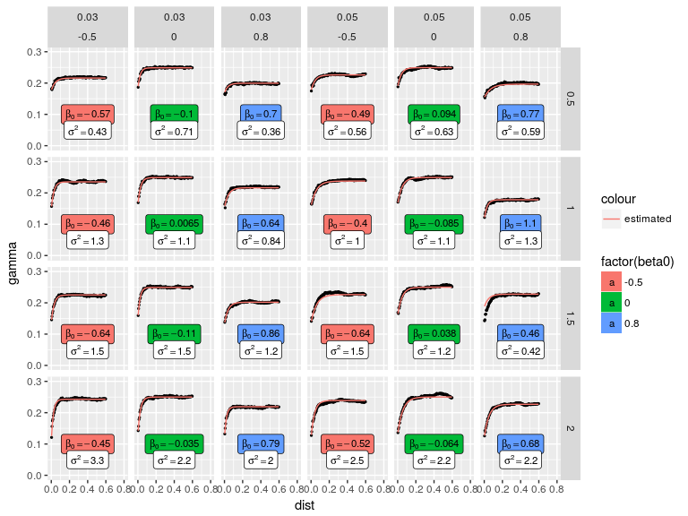

```r
est_df <- bi_vgs %>% dplyr::select(beta0:phi_est) %>% unique() %>%
  # mutate(label = paste(signif(beta0_est, 2), signif(sigma2_est, 2), sep = " & "))
  mutate(label_beta = paste0("beta[0] ==", signif(beta0_est, 2)),
         label_sigma = paste0("sigma^2 ==", signif(sigma2_est, 2)))
est_df$dist <- 0.4
est_df$gamma <- 0.1

ggplot(bi_vgs, aes(dist, gamma)) +
  geom_point(size = 0.5) +
  expand_limits(y = 0, x = 0) +
  scale_x_continuous(limits = c(0, 0.8)) +
  scale_y_continuous(limits = c(0, 0.3)) +
  geom_line(aes(y = vg_est, col = "estimated"), size = 0.5) +
  geom_label(aes(label = label_beta, fill = factor(beta0)), est_df, size = 3, parse = T) +
  geom_label(aes(y = 0.05, label = label_sigma), est_df, size = 3, parse = T) +
  facet_grid(sigma2 ~ phi + beta0, scales = "free")
```

This approach con be done using other correlation functions, likelihoods and link functions.